# Polarization

```r
## Pre-amble
knitr::opts_chunk$set(message = FALSE, fig.align = 'center')
library(dplyr)
library(ggplot2)
library(ggthemes)
library(directlabels) ## Great package to move labels on to figures
library(Rvoteview)
```

To explore the issue of polarization in congress over time, we will use the `Rvoteview` api to pull down some static files and directly query the database

```r
## Download the full member csv metadata file
members <- download_metadata('member')
## In most cases we would prefer you download the CSV from
## https://voteview.polisci.ucla.edu/data

## Load in state metadata that comes with Rvoteview
data(states)
```

```r
head(members, 3)
```

```
##        date_generated         id icpsr
## 1 2017-03-19 07:59:20 MH00106781  6781
## 2 2017-03-19 07:59:20 MH00103196  3196
## 3 2017-03-19 07:59:20 MH00101859  1859
##                                 bioname congress chamber cqlabel
## 1 MUHLENBERG, Frederick Augustus Conrad        1   House (PA-00)
## 2                    FITZSIMONS, Thomas        1   House (PA-00)
## 3                        CLYMER, George        1   House (PA-00)
##          state state_abbrev district_code party_code
## 1 Pennsylvania           PA            98       4000
## 2 Pennsylvania           PA            98       5000
## 3 Pennsylvania           PA            98       5000
##                  party_name  dim1   dim2 geo_mean_probability
## 1 Anti-Administration Party 0.236  0.437                   NA
## 2  Pro-Administration Party 0.535 -0.244                0.805
## 3  Pro-Administration Party 0.635 -0.772                0.871
##   number_of_errors number_of_votes log_likelihood
## 1               NA              NA             NA
## 2                4             107      -23.18736
## 3                5              96      -13.28171
```

```r
member_df <- merge(members, states, all.x = T, all.y = F, by = 'state_abbrev') %>%
  group_by(party_name) %>%
  mutate(n_icpsr_party = length(unique(icpsr)))
```

Now, let’s make some plots by party, state, region, and more! Let’s start out by tracking the two major parties over time.

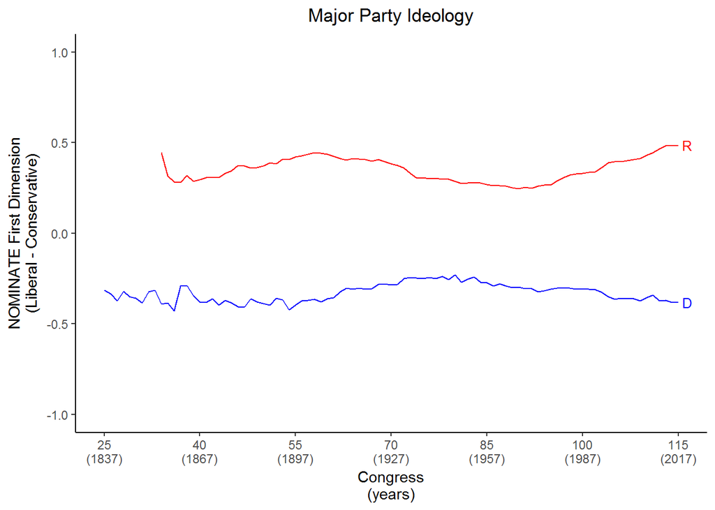

```r
party_df <- member_df %>%
  filter(chamber != 'President') %>%
  group_by(congress, party_name, party_code) %>%
  summarise(mean_dim1 = mean(dim1, na.rm = T),
            n_icpsr_party = mean(n_icpsr_party),
            r2_dims = cor(dim1, dim2, use = 'pairwise.complete.obs')^2)

cong_breaks <- seq(25, 115, by = 15)

ggplot(party_df[party_df$party_code %in% c(100, 200), ],
       aes(x = congress,
           y = mean_dim1,
           color = party_name)) +
  geom_line() +
  scale_y_continuous('NOMINATE First Dimension\n(Liberal - Conservative)',
                     limits = c(-1, 1),
                     breaks = seq(-1, 1, by = 0.5)) +
  scale_x_continuous('Congress\n(years)',
                     breaks = cong_breaks,
                     labels = paste0(cong_breaks,
                                     '\n(',
                                     (cong_breaks * 2) + 1787,
                                     ')')) +
  scale_color_manual('Party',
                     values = c('Democratic Party' = 'blue',
                                'Republican Party' = 'red')) +
  geom_dl(aes(label = substr(party_name, 1, 1)),
          method = list(dl.trans(x = x + 0.1),
                        "last.points",
                        cex = 0.8))  +
  ggtitle('Major Party Ideology') +
  theme_classic() +
  theme(plot.title = element_text(hjust = 0.5), legend.position='none')
```

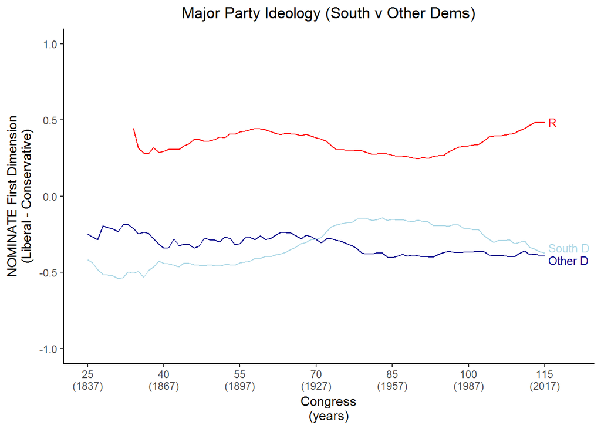

```r
edited_party_df <- member_df %>%
  filter(chamber != 'President') %>%
  mutate(edited_party = ifelse(party_name != 'Democratic Party',
                               substr(party_name, 1, 1),
                               ifelse(census_region_name == 'South',
                                      'South D',
                                      'Other D'))) %>%
  group_by(congress, edited_party, party_code) %>%
  summarise(mean_dim1 = mean(dim1, na.rm = T))

ggplot(edited_party_df[edited_party_df$party_code %in% c(100, 200), ],
       aes(x = congress,
           y = mean_dim1,
           color = edited_party)) +
  geom_line() +
  scale_y_continuous('NOMINATE First Dimension\n(Liberal - Conservative)',
                     limits = c(-1, 1),
                     breaks = seq(-1, 1, by = 0.5)) +
  scale_x_continuous('Congress\n(years)',
                     breaks = cong_breaks,
                     labels = paste0(cong_breaks,
                                     '\n(',
                                     (cong_breaks * 2) + 1787,
                                     ')'),
                     limits = c(25, 120)) +
  scale_color_manual('Party',
                     values = c('Other D' = 'darkblue',
                                'South D' = 'lightblue',
                                'R' = 'red')) +
  geom_dl(aes(label = edited_party),
          method = list(dl.trans(x = x + 0.1,
                                 y = ifelse(label == 'Other D',
                                            y - 0.15,
                                            ifelse(label != 'R', y + 0.15, y))),
                        "last.points",
                        cex = 0.8))  +
  ggtitle('Major Party Ideology (South v Other Dems)') +
  theme_classic() +
  theme(plot.title = element_text(hjust = 0.5), legend.position='none')
```

Now let’s break down the two major parties in each House.

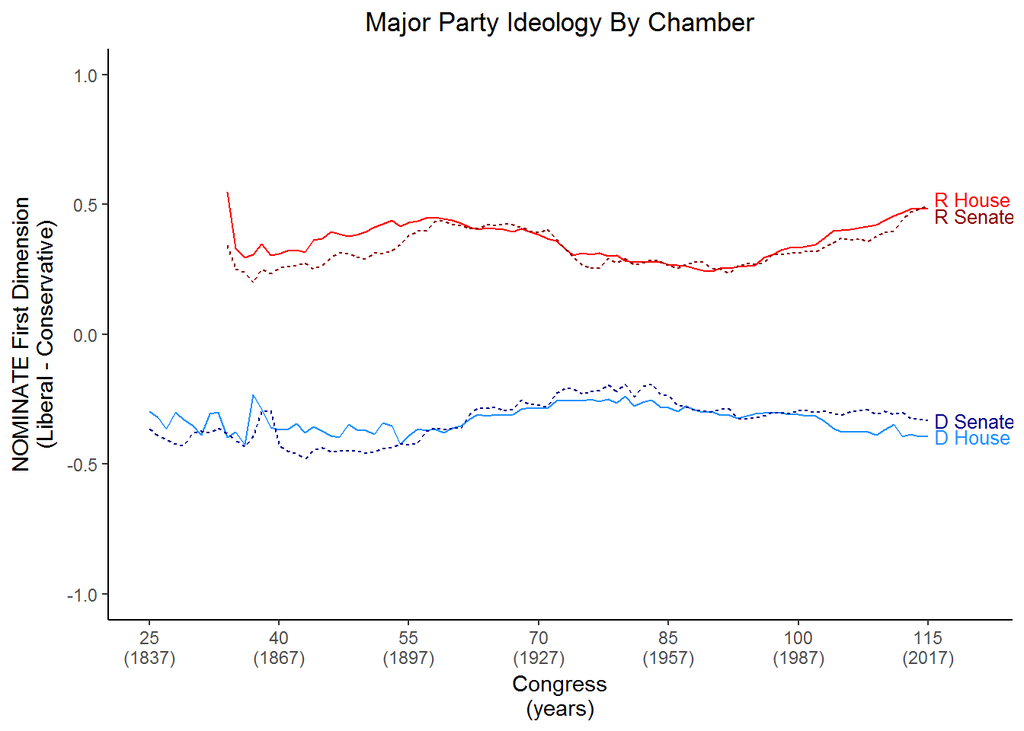

```r
party_chamb_df <- member_df %>%
  filter(chamber != 'President') %>%
  group_by(congress, chamber, party_name, party_code) %>%
  summarise(mean_dim1 = mean(dim1, na.rm = T)) %>%
  mutate(party_chamber = paste(substr(party_name, 1, 1),
                               chamber))

ggplot(party_chamb_df[party_chamb_df$party_code %in% c(100, 200), ],
       aes(x = congress,
           y = mean_dim1,
           color = party_chamber,
           linetype = chamber)) +
  geom_line() +
  scale_y_continuous('NOMINATE First Dimension\n(Liberal - Conservative)',
                     limits = c(-1, 1),
                     breaks = seq(-1, 1, by = 0.5)) +
  scale_x_continuous('Congress\n(years)',
                     breaks = cong_breaks,
                     labels = paste0(cong_breaks,
                                     '\n(',
                                     (cong_breaks * 2) + 1787,
                                     ')'),
                     limits = c(25, 120)) +
  scale_color_manual('Party',
                     values = c('D House' = 'dodgerblue',
                                'D Senate' = 'darkblue',
                                'R House' = 'red',
                                'R Senate' = 'darkred')) +
  geom_dl(aes(label = party_chamber),
          method = list(dl.trans(x = x + 0.1,
                                 y = ifelse(substr(label, 1, 1) == 'D',
                                            y,
                                            ifelse(label == 'R House',
                                                   y + 0.18,
                                                   y - 0.18))),
                        "last.points",
                        cex = 0.8))  +
  ggtitle('Major Party Ideology By Chamber') +
  theme_classic() +
  theme(plot.title = element_text(hjust = 0.5), legend.position='none')
```

We can also get all major parties (parties who have had over 100 distinct members) throughout history:

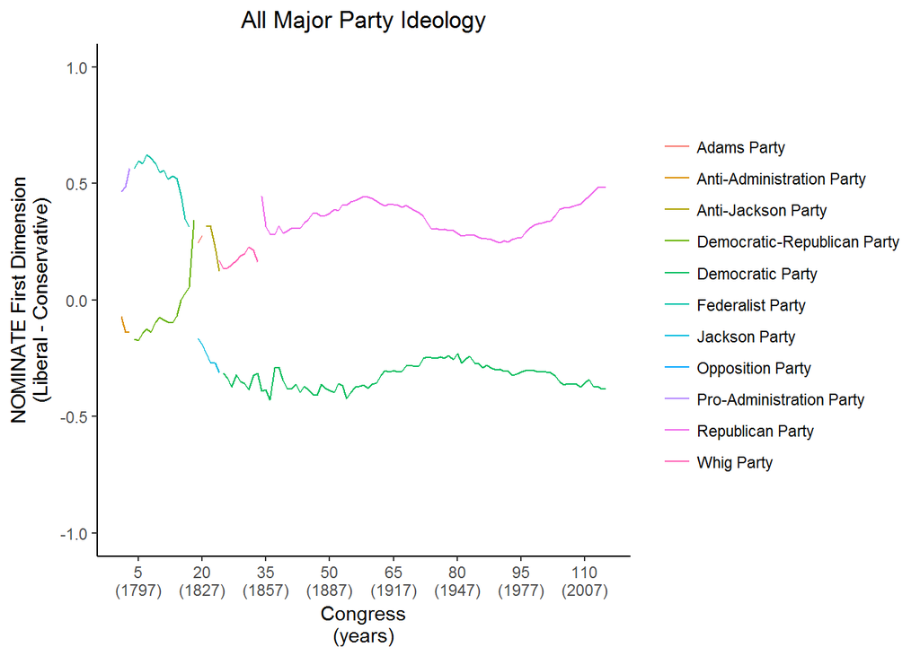

```r
cong_breaks <- seq(5, 115, by = 15)
ggplot(party_df[party_df$n_icpsr_party > 100, ],
       aes(x = congress,
           y = mean_dim1,
           color = party_name)) +
  geom_line() +
  scale_y_continuous('NOMINATE First Dimension\n(Liberal - Conservative)',
                     limits = c(-1, 1),
                     breaks = seq(-1, 1, by = 0.5)) +
  scale_x_continuous('Congress\n(years)',
                     breaks = cong_breaks,
                     limits = c(1, 115),
                     labels = paste0(cong_breaks,
                                     '\n(',
                                     (cong_breaks * 2) + 1787,
                                     ')')) +
  ggtitle('All Major Party Ideology') +
  theme_classic() +
  theme(plot.title = element_text(hjust = 0.5), legend.title = element_blank())
```

What about how the two dimensions are correlated within party over time? Here we plot the percent of the variance each dimension explains of the other. You see that at the peak of the Southern Democrats control of the South, from the first World War through the Civil Rights movement, knowing the first dimension of Democratic candidates helped you explain where they were on the second dimension.

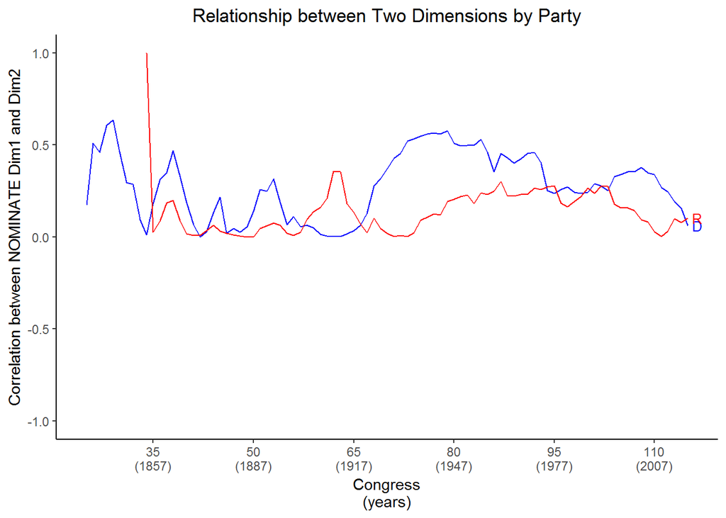

```r
ggplot(party_df[party_df$party_code %in% c(100, 200), ],
       aes(x = congress,
           y = r2_dims,
           color = party_name)) +
  geom_line() +
  scale_y_continuous('Correlation between NOMINATE Dim1 and Dim2',
                     limits = c(-1, 1),
                     breaks = seq(-1, 1, by = 0.5)) +
  scale_x_continuous('Congress\n(years)',
                     breaks = cong_breaks,
                     labels = paste0(cong_breaks,
                                     '\n(',
                                     (cong_breaks * 2) + 1787,
                                     ')')) +
  scale_color_manual('Party',
                     values = c('Democratic Party' = 'blue',
                                'Republican Party' = 'red')) +
  geom_dl(aes(label = substr(party_name, 1, 1)),
          method = list(dl.trans(x = x + 0.1),
                        "last.points",
                        cex = 0.8))  +
  ggtitle('Relationship between Two Dimensions by Party') +
  theme_classic() +
  theme(plot.title = element_text(hjust = 0.5), legend.position='none')
```

Lastly,let’s see how averages have changed over time in the different census regions for both dimensions. We can see the South becoming more conservative over time, and strikingly a converge across regions along the second dimension, as racial issues no longer so clearly divide the regions.

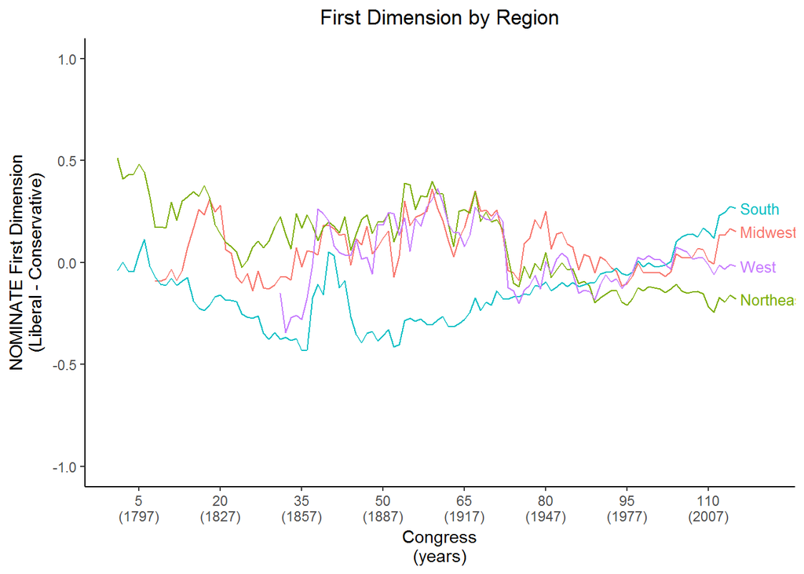

```r
region_df <- member_df %>%
  filter(chamber != 'President') %>%
  group_by(congress, census_region_name) %>%
  summarise(mean_dim1 = mean(dim1, na.rm = T),
            mean_dim2 = mean(dim2, na.rm = T))

ggplot(region_df,
       aes(x = congress,
           y = mean_dim1,
           color = census_region_name)) +
  geom_line() +
  scale_y_continuous('NOMINATE First Dimension\n(Liberal - Conservative)',
                     limits = c(-1, 1),
                     breaks = seq(-1, 1, by = 0.5)) +
  scale_x_continuous('Congress\n(years)',
                     breaks = cong_breaks,
                     limits = c(1, 120),
                     labels = paste0(cong_breaks,
                                     '\n(',
                                     (cong_breaks * 2) + 1787,
                                     ')')) +
    geom_dl(aes(label = census_region_name),
          method = list(dl.trans(x = x + 0.1),
                        "last.points",
                        cex = 0.8))  +
  ggtitle('First Dimension by Region') +
  theme_classic() +
  theme(plot.title = element_text(hjust = 0.5), legend.position = 'none')
```

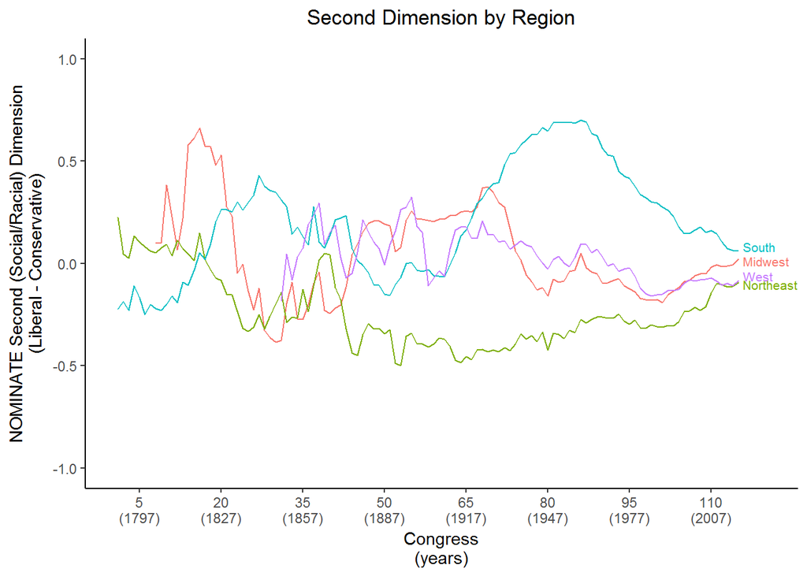

```r
ggplot(region_df,
       aes(x = congress,
           y = mean_dim2,
           color = census_region_name)) +
  geom_line() +
  scale_y_continuous('NOMINATE Second (Social/Racial) Dimension\n(Liberal - Conservative)',
                     limits = c(-1, 1),
                     breaks = seq(-1, 1, by = 0.5)) +
  scale_x_continuous('Congress\n(years)',
                     breaks = cong_breaks,
                     limits = c(1, 120),
                     labels = paste0(cong_breaks,
                                     '\n(',
                                     (cong_breaks * 2) + 1787,
                                     ')')) +
  geom_dl(aes(label = census_region_name),
          method = list(dl.trans(x = x + 0.1,
                                 y = ifelse(label %in% c('South', 'West'),
                                            y + 0.1,
                                            y - 0.06)),
                        "last.points",
                        cex = 0.65))  +
  ggtitle('Second Dimension by Region') +
  theme_classic() +
  theme(plot.title = element_text(hjust = 0.5), legend.position = 'none')
```